# R Package Rgof

```r
library(Rgof)
Bsim = 500 #Number of Simulation Runs
```

Note that Bsim is very small, so that this vignette does not take to long to run. Therefore none of the p values or powers below are correct.

The package *Rgof* brings together a number of routines for the goodness-of-fit problem for univariate data. We have a data set $\pmb{x}$, and we want to test whether it was generated by the probability distribution F.

The highlights of this package are:

- it runs a large number of different tests simultaneously.
- it can run several tests and find an adjusted p value for the combination of all the tests.
- it works for continuous and for discrete (aka histogram) data.
- it allows for parameter estimation.
- it uses Rcpp and parallel programming to be very fast.
- it includes routines that make it very easy to estimate the power of the different tests for specific situations.
- it allows for the possibility that the sample size was a draw from a Poisson random variable.
- it allows the user to add more tests.
- it includes a routine to draw the usual power graph.
- it allows the user to compare the power of a new test to those included in the package for a large number of cases (aka null hypothesis vs alternative hypothesis).

```r
set.seed(123)
```

**Note** all runs of the test routine are done with *B=1000* and all runs of the power routines with arguments *B=500* in order to pass *devtools::check()*.

## The Methods

- **Continuous Data**
1. Kolmogorov Smirnov (KS) (Massey 1951), (Kolmogorov 1933), (Smirnov 1948)
2. Kuiper (K) (Kuiper 1960)
3. Anderson-Darling (AD) (Anderson and Darling 1952), (Anderson and Darling 1954)
4. Cramer-vonMises (CvM) (Anderson 1962)
5. Wilson (W)
6. Zhang’s methods (ZA, ZK, ZC) (Zhang 2002)
7. Wasserstein p=1 (Wassp1) (E del Barrio 1999)

For all of these tests the distribution of the test statistic under the null hypothesis is found via simulation.

8. Eight variations of chi square tests, using the formulas by Pearson or based on the likelihood ratio test, bins of equal size or equal probability and both a large number and a small number of bins, 50 and 10 by default. The p values are found using the usual chi square approximation to the null distribution. If parameters are estimated this is done either via the method of minimum chi square (Berkson 1980) or via a user-provided estimator. In all cases bins are combined until all of them have an expected count of at least 5.

There is a very large literature on chi square tests, the oldest of the goodness of fit tests. For a survey see (Rolke and Gutierrez-Gongora 2020).

- **Discrete (Histogram) Data**

All the methods above are also implemented for discrete data, except for Zhang’s tests, which have no discrete analog.

It is worth noting that these discrete versions are based on the theoretical ideas of the tests and not on the actual formula of calculation for the continuous case. The test statistics can therefore be different even when applied to the same data. For example, the Anderson-Darling test is based on the distance measure

$$A^2=n\int_{-\infty}^{\infty}
\frac{(\hat{F}(x)-F(x))^2}{F(x)(1-F(x))}dF(x)$$
where $F$ is the theoretical distribution function under the null hypothesis and $\hat{F}$ is the empirical distribution function. In the case of continuous data it can be shown that

$$A^2=-n-\frac1n\sum_{i=1}^n
(2i-1)\left(\log F(x_i) +\log[1-F(x_{n+1-i})\right)$$
However, for discrete data we have

$$A^2=n\sum_{i=1}^k
\frac{(\hat{F}(x_i)-F(x_i))^2}{F(x_i)(1-F(x_i))}\left(F(x_i)-F(x_{i-1}\right)$$

with $F(x_0)=0$.

In the continuous case $\hat{F}$ is a step function but $F$ is continuous, and therefore $A^2>0$. In the discrete case however$A^2=0$ is possible. This shows that the two cases are fundamentally different and therefore require different formulas for the test statistic.

As for continuous data null distributions are found using simulation. In fact in the case of discrete data none of the tests has a known distribution for the test statistic under the null hypothesis.

8. Four variations of chi square tests, using the formulas by Pearson and log-likelihood as well as a large number and a small number of bins. Again the routine combines bins until all have expected counts greater than 5, and the chi square approximation is used to find p values. The combination of bins is done in such a way that the bins remain of equal size as much as possible.

These methods can be used for both discrete and histogram data. The main difference between these two is that discrete data has (a countable) number of possible values whereas histogram data has possible ranges of values (the bins). The only method directly affected by this difference is Wassp1, which requires actual values. All other methods ignore the *vals* argument.

## Testing

### Discrete (Histogram) Data/Model

#### Simple Null Hypothesis

We generate a data set of size 1000 from a Binomial distribution with n=20 and success probability 0.5, and then test $H_0:F=Bin(20, 0.5)$.

```r
vals=0:20 #possible values of random variable
pnull=function()  pbinom(0:20, 20, 0.5)  # cumulative distribution function (cdf)
rnull = function() table(c(0:20, rbinom(1000, 20, 0.5)))-1
# generate data under the null hypothesis, make sure that vector of counts has
#same length as vals, possibly 0.
```

- **Null Hypothesis is true**

```r
x = rnull()
# Basic Test
gof_test(x, vals, pnull, rnull, B=1000)
```

```
#> maxProcessor set to 1 for faster computation
#> $statistics
#>      KS       K      AD     CvM       W  Wassp1     l-P     s-P     l-L     s-L
#> 0.17000 0.17380 0.13280 0.02492 2.04530 0.03457 2.60110 1.95330 2.67520 2.03780
#>
#> $p.values
#>     KS      K     AD    CvM      W Wassp1    l-P    s-P    l-L    s-L
#> 0.6640 0.7570 0.9960 0.9680 0.6670 0.9960 0.9978 0.9967 0.9974 0.9960
```

```r
#Test with adjusted overall p value
gof_test_adjusted_pvalue(x, vals, pnull, rnull, B=c(1000, 500))
```

[output not shown]

- **Null Hypothesis is false**

```r
x = table(c(0:20, rbinom(1000, 20, 0.55)))-1
#true p is 0.55, not 0.5
# Basic Test
gof_test(x, vals, pnull, rnull, B=1000, doMethod = "all")$p.value
```

```
#> maxProcessor set to 1 for faster computation
#>     KS      K     AD    CvM      W Wassp1    l-P    s-P    l-L    s-L
#>      0      0      0      0      0      0      0      0      0      0
```

```r
#Test with adjusted overall p value
gof_test_adjusted_pvalue(x, vals, pnull, rnull, B=c(1000, 500))
```

[output not shown]

Arguments of *gof_test* for discrete data/model:

- x: vector with counts (histogram heights). Should have a number for each value of vals, possibly 0.
- vals: all possible values of discrete random variable, that is all x with $P(X=x)>0$
- pnull: function to find values of cumulative distribution function for each value of vals. Function has no arguments.
- rnull: function to generate data from true density. Function has no arguments. Function needs to insure that output is a vector with same length as vals.
- B=5000: number of simulation runs
- w: function to find importance sampling weights, if needed
- phat: function to estimate parameters
- TS: function to find values of user-supplied test statistics
- TSextra: a list that is passed to TS if any additional info is required.
- nbins=c(50, 10): number of bins for chi square tests. The first one is already given by the data in the discrete case, for the second bins are joined.
- rate=0, if not 0 sample size is assumed to have come from a Poisson random variable with rate “rate”.
- minexpcount=5, minimal expected counts for chi square tests.
- ChiUsePhat=TRUE, if TRUE uses user supplied function phat for parameter estimation. If false uses method of minimum chi square.
- maxProcessor=1 if greater than 1 number of cores for parallel processing. Parallel processing is usually not be useful for discrete data as the single thread version generally runs faster.
- doMethods=“all” names of methods to include

The arguments of *gof_test_adjusted_pvalue* for discrete data/model are the same, except that the number of simulation runs B is two numbers. The first is used for estimating the individual p values, the second for the adjustment.

#### Random Sample Size

In some fields like high energy physics it is common that the sample size is not fixed but a random variable drawn from a Poisson distribution with a known rate. Our package runs this as follows:

```r
rnull = function() table(c(0:20, rbinom(rpois(1, 650), 20, 0.5)))-1
x = rnull()
gof_test(x, vals, pnull, rnull, rate=650, B=1000)$p.value
```

```
#> maxProcessor set to 1 for faster computation
#>     KS      K     AD    CvM      W Wassp1    l-P    s-P    l-L    s-L
#> 0.0650 0.0640 0.1710 0.1200 0.0450 0.1880 0.4898 0.4898 0.4446 0.4446
```

#### Composite Null Hypothesis

We generate a data set of size 1000 from a binomial distribution with n=20 and success probability p, and then test F=Bin(20, .). p is estimated from data.

```r
vals=0:20
pnull=function(p=0.5)  pbinom(0:20, 20, ifelse(p>0&&p<1, p, 0.5))
rnull = function(p=0.5) table(c(0:20, rbinom(1000, 20, p)))-1
phat = function(x) sum(0:20*x)/sum(x)/20
```

- **Null Hypothesis is true**

```r
x = table(c(0:20, rbinom(1000, 20, 0.5)))-1
gof_test(x, vals, pnull, rnull, phat=phat, B=1000)$p.value
```

```
#> maxProcessor set to 1 for faster computation
#>     KS      K     AD    CvM      W Wassp1    l-P    s-P    l-L    s-L
#> 0.0450 0.0660 0.2130 0.0900 0.0980 0.2670 0.4664 0.5043 0.4638 0.5138
```

- **Null Hypothesis is true**

```r
x = table(c(0:20, rbinom(1000, 20, 0.55)))-1
# p is not 0.5, but data is still from a binomial distribution with n=20
gof_test(x, vals, pnull, rnull, phat=phat, B=1000)$p.value
```

```
#> maxProcessor set to 1 for faster computation
#>     KS      K     AD    CvM      W Wassp1    l-P    s-P    l-L    s-L
#> 0.4350 0.5880 0.9410 0.9880 0.5960 0.9770 0.8126 0.9922 0.8415 0.9928
```

- **Null Hypothesis is false**

```r
x = table(c(rep(0:20, 5), rbinom(1000-21*5, 20, 0.53)))
# data has to many small and large values to be from a binomial
gof_test(x, vals, pnull, rnull, phat=phat, B=1000)$p.value
```

```
#> maxProcessor set to 1 for faster computation
#>     KS      K     AD    CvM      W Wassp1    l-P    s-P    l-L    s-L
#>  0.022  0.003  0.000  0.001  0.002  0.000  0.000  0.000  0.000  0.000
```

The arguments are the same as for the simple hypothesis case, except that the user has to supply a routine phat to estimate the parameters, and the functions pnull and rnull now have one argument, namely the vector with parameter estimates.

The estimation of the parameter(s) in the case of the chi square tests is done either by using the function phat or via the minimum chi square method. The routine uses a general function minimizer. If there are values of the parameter that are not possible this can lead to warnings. It is best to put a check into the pnull function to avoid this issue. As an example the function pnull above checks that the success probability p is in the interval $(0,1)$.

### Histogram Data

A variant of discrete data sometimes encountered is data given in the form of a histogram, that is as a set of bins and their counts. The main distinction is that discrete data has specific values, for example the non-negative integers for a Poisson distribution, whereas histogram data has ranges of numbers, the bins. It turns out that, though, that the only method that requires actual values is Wassp1, and for that method one can use the midpoint of the intervals.

As an example consider the following case: we have histogram data and we want to test whether it comes from an exponential rate 1 distribution, truncated to the interval 0-2:

```r
rnull = function() {
  y = rexp(2500, 1) # Exp(1) data
  y = y[y<2][1:1500] # 1500 events on 0-2
  bins = 0:40/20 # binning
  hist(y, bins, plot=FALSE)$counts # find bin counts
}
x = rnull()
bins = 0:40/20
vals = (bins[-1]+bins[-21])/2 #use bin midpoints as values
pnull = function() {
   bins = 1:40/20
   pexp(bins, 1)/pexp(2, 1)
}

gof_test(x, vals, pnull, rnull)$p.value
```

```
#> maxProcessor set to 1 for faster computation
#>     KS      K     AD    CvM      W Wassp1    l-P    s-P    l-L    s-L
#> 0.4826 0.9380 0.7498 0.6906 0.5988 0.7022 0.3660 0.9415 0.3261 0.9420
```

### Continuous Data

#### Simple Hypothesis

```r
pnull = function(x) pnorm(x)
rnull = function()  rnorm(1000)
TSextra = list(qnull=function(x) qnorm(x)) #optional quantile function used by chi square tests and Wassp1 test.
```

- **Null Hypothesis is true**

```r
x = rnorm(1000)
#Basic Tests
gof_test(x, NA, pnull, rnull, B=1000, TSextra=TSextra)$p.value
```

```
#> maxProcessor set to 1 for faster computation
#>     KS      K     AD    CvM      W     ZA     ZK     ZC Wassp1 ES-l-P ES-s-P
#> 0.5150 0.5150 0.4860 0.7090 0.7240 0.3040 0.1970 0.3730 0.5710 0.2651 0.2139
#> EP-l-P EP-s-P ES-l-L ES-s-L EP-l-L EP-s-L
#> 0.9941 0.5313 0.1246 0.1735 0.9875 0.5149
```

```r
#Adjusted p value
gof_test_adjusted_pvalue(x, NA, pnull, rnull, B=c(1000,500), TSextra=TSextra)
```

[output not shown]

- **Null Hypothesis is false**

```r
x = rnorm(1000, 0.5)
gof_test(x, NA, pnull, rnull, B=1000, TSextra=TSextra)$p.value
```

```
#> maxProcessor set to 1 for faster computation
#>     KS      K     AD    CvM      W     ZA     ZK     ZC Wassp1 ES-l-P ES-s-P
#>      0      0      0      0      0      0      0      0      0      0      0
#> EP-l-P EP-s-P ES-l-L ES-s-L EP-l-L EP-s-L
#>      0      0      0      0      0      0
```

#### Composite Hypothesis - One Parameter

```r
pnull = function(x, p=0) pnorm(x, p)
TSextra = list(qnull = function(x, p=0) qnorm(x, p))
rnull = function(p)  rnorm(1000, p)
phat = function(x) mean(x)
```

- **Null Hypothesis is true**

```r
x = rnorm(1000)
gof_test(x, NA, pnull, rnull, phat=phat, TSextra=TSextra, B=1000)$p.value
```

```
#> maxProcessor set to 1 for faster computation
#>     KS      K     AD    CvM      W     ZA     ZK     ZC Wassp1 ES-l-P ES-s-P
#> 0.3530 0.3530 0.3050 0.3020 0.2950 0.0360 0.2060 0.0640 0.2370 0.6706 0.3258
#> EP-l-P EP-s-P ES-l-L ES-s-L EP-l-L EP-s-L
#> 0.2184 0.7251 0.6557 0.2340 0.1349 0.7057
```

- **Null Hypothesis is true**

```r
x = rnorm(1000, 0.5)
gof_test(x, NA, pnull, rnull, phat=phat, TSextra=TSextra)$p.value
```

```
#> maxProcessor set to 1 for faster computation
#>     KS      K     AD    CvM      W     ZA     ZK     ZC Wassp1 ES-l-P ES-s-P
#> 0.3948 0.3948 0.3092 0.4534 0.4224 0.7268 0.3164 0.6494 0.3466 0.2126 0.1409
#> EP-l-P EP-s-P ES-l-L ES-s-L EP-l-L EP-s-L
#> 0.8922 0.1182 0.1965 0.1364 0.8785 0.1150
```

- **Null Hypothesis is false**

```r
x = rnorm(1000, 0.5, 2)
gof_test(x, NA, pnull, rnull, phat=phat, TSextra=TSextra, B=1000)$p.value
```

```
#> maxProcessor set to 1 for faster computation
#>     KS      K     AD    CvM      W     ZA     ZK     ZC Wassp1 ES-l-P ES-s-P
#>      0      0      0      0      0      0      0      0      0      0      0
#> EP-l-P EP-s-P ES-l-L ES-s-L EP-l-L EP-s-L
#>      0      0      0      0      0      0
```

The arguments of gof_test are the same as in the discrete case, except that vals=NA. The functions pnull and rnull are functions of one variable in the case of a simple hypothesis and of two variables in the case of parameeter estimation.

#### Composite Hypothesis - Multiple Parameters

```r
pnull = function(x, p=c(0, 1)) pnorm(x, p[1], ifelse(p[2]>0, p[2], 0.001))
TSextra = list(qnull = function(x, p=c(0, 1)) qnorm(x, p[1], ifelse(p[2]>0, p[2], 0.001)))
rnull = function(p=c(0, 1))  rnorm(1000, p[1], ifelse(p[2]>0, p[2], 0.001))
phat = function(x) c(mean(x), sd(x))
```

- **Null Hypothesis is true**

```r
x = rnorm(1000)
gof_test(x, NA, pnull, rnull, phat=phat, TSextra=TSextra, B=1000)$p.value
```

```
#> maxProcessor set to 1 for faster computation
#>     KS      K     AD    CvM      W     ZA     ZK     ZC Wassp1 ES-l-P ES-s-P
#> 0.9750 0.9750 0.8330 0.8860 0.9400 0.7180 0.3160 0.6410 0.7750 0.2062 0.6863
#> EP-l-P EP-s-P ES-l-L ES-s-L EP-l-L EP-s-L
#> 0.6912 0.7844 0.1368 0.6972 0.6437 0.7941
```

- **Null Hypothesis is true**

```r
x = rnorm(1000, 0.5)
gof_test(x, NA, pnull, rnull, phat=phat, TSextra=TSextra, B=1000)$p.value
```

```
#> maxProcessor set to 1 for faster computation
#>     KS      K     AD    CvM      W     ZA     ZK     ZC Wassp1 ES-l-P ES-s-P
#> 0.8550 0.8550 0.6480 0.7910 0.7590 0.7520 0.6960 0.8190 0.6180 0.6737 0.8498
#> EP-l-P EP-s-P ES-l-L ES-s-L EP-l-L EP-s-L
#> 0.3298 0.6819 0.6589 0.8427 0.2823 0.6862
```

- **Null Hypothesis is true**

```r
x = rnorm(1000, 0.5, 2)
gof_test(x, NA, pnull, rnull, phat=phat, TSextra=TSextra, B=1000)$p.value
```

```
#> maxProcessor set to 1 for faster computation
#>     KS      K     AD    CvM      W     ZA     ZK     ZC Wassp1 ES-l-P ES-s-P
#> 0.3220 0.3220 0.4740 0.4960 0.4540 0.3740 0.2130 0.3550 0.4540 0.2479 0.0660
#> EP-l-P EP-s-P ES-l-L ES-s-L EP-l-L EP-s-L
#> 0.4932 0.2673 0.2335 0.0686 0.4889 0.2618
```

- **Null Hypothesis is false**

```r
x = rt(1000, 2)
gof_test(x, NA, pnull, rnull, phat=phat, TSextra=TSextra, B=1000)$p.value
```

```
#> maxProcessor set to 1 for faster computation
#>     KS      K     AD    CvM      W     ZA     ZK     ZC Wassp1 ES-l-P ES-s-P
#> 0.0000 0.0000 0.0000 0.0000 0.0000 0.0000 0.0000 0.0000 0.0000 0.0000 0.0006
#> EP-l-P EP-s-P ES-l-L ES-s-L EP-l-L EP-s-L
#> 0.0000 0.0000 0.0000 0.0014 0.0000 0.0000
```

## Power Estimation

For estimating the power of the various tests one also has to provide the routine *ralt*, which generates data under the alternative hypothesis:

### Discrete Data/Model

#### Simple Null Hypothesis

```r
vals = 0:10
pnull = function() pbinom(0:10, 10, 0.5)
rnull =function () table(c(0:10, rbinom(100, 10, 0.5)))-1
ralt =function (p=0.5) table(c(0:10, rbinom(100, 10, p)))-1
P=gof_power(pnull, vals, rnull, ralt,
  param_alt=seq(0.5, 0.6, 0.02), B=Bsim, nbins=c(11, 5))
```

```
#> maxProcessor set to 1 for faster computation
```

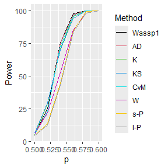

```r
plot_power(P, "p", Smooth=FALSE)
```

In all cases the arguments are the same as for *gof_test*. In addition we now have

- ralt: a routine with one parameter that generates data under some alternative hypothesis.
- param_alt: values to be passed to ralt. This allows the calculation of the power for many different values.
- alpha=0.05 type I error probability for tests.
- B=1000 the number of simulation runs.

#### Composite Null Hypothesis

```r
vals = 0:10
pnull = function(p=0.5) pbinom(0:10, 10, ifelse(0<p&p<1,p,0.001))
rnull = function (p=0.5) table(c(0:10, rbinom(100, 10, ifelse(0<p&p<1,p,0.001))))-1
phat = function(x) sum(0:10*x)/1000
```

- **Null Hypothesis is true**

```r
ralt =function (p=0.5) table(c(0:10, rbinom(100, 10, p)))-1
gof_power(pnull, vals, rnull, ralt, c(0.5, 0.6), phat=phat,
        B=Bsim, nbins=c(11, 5), maxProcessor = 2)
```

```
#> maxProcessor set to 1 for faster computation
#>        KS     K    AD  CvM     W Wassp1   l-P   s-P
#> 0.5 0.032 0.044 0.034 0.04 0.044  0.048 0.072 0.072
#> 0.6 0.046 0.048 0.052 0.06 0.058  0.056 0.058 0.058
```

Note that power estimation in the case of a composite hypothesis (aka with parameters estimated) is much slower than the simple hypothesis case.

- **Null Hypothesis is false**

```r
ralt =function (p=0.5) table(c(rep(0:10, 2), rbinom(100, 10, p)))
gof_power(pnull, vals, rnull, ralt, 0.5, phat=phat,
        B=Bsim, nbins=c(11, 5), maxProcessor = 2)
```

```
#> maxProcessor set to 1 for faster computation
#>     KS      K     AD    CvM      W Wassp1    l-P    s-P
#>  0.100  0.274  1.000  1.000  0.586  1.000  1.000  1.000
```

### Continuous Data/Model

#### Simple Null Hypothesis

```r
pnull = function(x) pnorm(x)
TSextra = list(qnull = function(x) qnorm(x))
rnull = function() rnorm(100)
ralt = function(mu=0) rnorm(100, mu)
gof_power(pnull, NA, rnull, ralt, c(0, 1), TSextra=TSextra, B=Bsim)
```

```
#> maxProcessor set to 1 for faster computation
#>      KS     K    AD   CvM     W    ZA    ZK   ZC Wassp1 ES-l-P ES-s-P EP-l-P
#> 0 0.028 0.028 0.034 0.022 0.038 0.036 0.054 0.03  0.042  0.052  0.064  0.062
#> 1 1.000 1.000 1.000 1.000 1.000 1.000 1.000 1.00  1.000  1.000  1.000  1.000
#>   EP-s-P ES-l-L ES-s-L EP-l-L EP-s-L
#> 0  0.056   0.06   0.06   0.07   0.07
#> 1  1.000   1.00   1.00   1.00   1.00
```

#### Composite Null Hypothesis

```r
pnull = function(x, p=c(0,1)) pnorm(x, p[1], ifelse(p[2]>0, p[2], 0.01))
TSextra = list(qnull = function(x, p=c(0,1)) qnorm(x, p[1], ifelse(p[2]>0, p[2], 0.01)))
rnull = function(p=c(0,1)) rnorm(500, p[1], p[2])
ralt = function(mu=0) rnorm(100, mu)
phat = function(x) c(mean(x), sd(x))
gof_power(pnull, NA, rnull, ralt, c(0, 1), phat= phat,
          TSextra=TSextra, B=Bsim, maxProcessor=2)
```

```
#> maxProcessor set to 1 for faster computation
#>      KS     K    AD   CvM     W    ZA    ZK   ZC Wassp1 ES-l-P ES-s-P EP-l-P
#> 0 0.962 0.918 0.066 0.078 0.072 0.574 0.014 0.02  0.994  0.046   0.06  0.050
#> 1 0.966 0.918 0.058 0.068 0.066 0.590 0.004 0.02  0.996  0.060   0.07  0.062
#>   EP-s-P ES-l-L ES-s-L EP-l-L EP-s-L
#> 0  0.044  0.050  0.064  0.048  0.058
#> 1  0.066  0.058  0.066  0.068  0.070
```

```r
ralt = function(df=1) {
# t distribution truncated at +- 5
  x=rt(1000, df)
  x=x[abs(x)<5]
  x[1:100]
}
gof_power(pnull, NA, rnull, ralt, c(2, 50), phat=phat,
          Range=c(-5,5), TSextra=TSextra, B=Bsim, maxProcessor=2)
```

```
#> maxProcessor set to 1 for faster computation
#>       KS     K    AD   CvM     W    ZA    ZK    ZC Wassp1 ES-l-P ES-s-P EP-l-P
#> 2  0.998 0.996 0.622 0.616 0.632 0.964 0.236 0.200  1.000  0.286  0.360  0.258
#> 50 0.964 0.922 0.048 0.052 0.046 0.626 0.014 0.024  0.574  0.054  0.066  0.064
#>    EP-s-P ES-l-L ES-s-L EP-l-L EP-s-L
#> 2   0.308  0.294  0.374   0.26  0.324
#> 50  0.046  0.054  0.072   0.08  0.060
```

### Running other tests

Its is very easy for a user to add other goodness-of-fit tests to the package. This can be done by editing the routines **TS_cont** and/or **TS_disc**, which are located in the folder *inst/examples* in the Rgof library folder. Or a user can write their own version of these files.

**Example**

Say we wish to use a test that is a variant of the Cramer-vonMises test, using the integrated absolute difference of the empirical and the theoretical distribution function:

$$\int_{-\infty}^{\infty} \vert F(x) -
\hat{F}(x) \vert dF(x)$$
For continuous data we have the routine

```r
newTScont = function(x, pnull, param) {
   Fx=sort(pnull(x))
   n=length(x)
   out = sum(abs( (2*1:n-1)/2/n-Fx ))
   names(out) = "CvM alt"
   out
}
```

This routine has to have three or four arguments x, pnull, param and (optionally) TSextra. x is the data and pnull a function that finds the cdf at x. param has to be the estimated parameters in the case of a composite null hypothesis, and is ignored in the case of a simple null hypothesis. Tsextra has to be a list of additional items needed for the calculation of the test statistic.

Note that the return object has to be a **named** vector.

Then we can run this test with

```r
pnull = function(x) punif(x)
rnull = function() runif(500)
x = rnull()
Rgof::gof_test(x, NA, pnull, rnull, TS=newTScont)
```

```
#> maxProcessor set to 1 for faster computation
#> $statistics
#> CvM alt
#>  11.683
#>
#> $p.values
#> CvM alt
#>  0.0834
```

Say we want to find the power of this test when the true distribution is a linear:

```r
ralt = function(slope=0) {
  if(slope==0) y=runif(500)
    else y=(slope-1+sqrt((1-slope)^2+4*slope* runif(500)))/2/slope
}
```

```r
gof_power(pnull, NA, rnull, ralt, TS=newTScont, param_alt=round(seq(0, 0.5, length=3), 3), Range=c(0,1), B=Bsim)
```

```
#> maxProcessor set to 1 for faster computation
#>      CvM alt
#> 0      0.062
#> 0.25   0.910
#> 0.5    1.000
```

for discrete data we will write the routine using Rcpp:

(For reasons to avoid issues with CRAN submission this routine is already part of Rgof)

```cpp
#include <Rcpp.h>
using namespace Rcpp;
// [[Rcpp::export]]
NumericVector newTSdisc(IntegerVector x,
                      Function pnull,
                      NumericVector param,
                      NumericVector vals) {

  Rcpp::CharacterVector methods=CharacterVector::create("CvM alt");
  int const nummethods=methods.size();
  int k=x.size(), n, i;
  NumericVector TS(nummethods), ecdf(k), Fx(k);
  double tmp;
  TS.names() =  methods;
  Fx=pnull(param);
  n=0;
  for(i=0;i<k;++i) n = n + x[i];
  ecdf(0) = double(x(0))/double(n);
  for(i=1;i<k;++i) {
    ecdf(i) = ecdf(i-1) + x(i)/double(n);
  }

  tmp = std::abs(ecdf[0]-Fx(0))*Fx(0);
  for(i=1;i<k;++i)
     tmp = tmp + std::abs(ecdf(i)-Fx(i))*(Fx(i)-Fx(i-1));
  TS(0) = tmp;

  return TS;
}
```

The routine has to have four or five arguments x, pnull, param, vals and (optionally) TSextra. The output vector has to have names.

Note that one drawback of writing the routine in Rcpp is that it is then not possible to use multiple processors.

As an example we will test whether some data comes from a Binomial distribution with n=10 trials. The success parameter p will be estimated from the data:

```r
vals=0:10
pnull = function(p) pbinom(0:10, 10, p)
rnull = function(p) table(c(0:10,rbinom(10000, 10, p)))-1
phat=function(x) sum(0:10*x)/100000
x = rnull(0.5)
gof_test(x, vals, pnull, rnull, phat=phat, TS=Rgof::newTSdisc)
```

```
#> maxProcessor set to 1 for faster computation
#> $statistics
#>  CvM alt      l-P      s-P      l-L      s-L
#> 0.001749 8.629200 3.130700 8.646800 3.128500
#>
#> $p.values
#> CvM alt     l-P     s-P     l-L     s-L
#>  0.6074  0.4722  0.9259  0.4705  0.9260
```

For the power calculations we will consider data that is actually a mixture of two Binomials:

```r
ralt = function(tau=0) {
   x=rbinom(5000, 10, 0.5-tau)
   y=rbinom(5000, 10, 0.5+tau)
   table(c(0:10,x,y))-1
}
gof_power(pnull, vals, rnull, ralt,
    TS=Rgof::newTSdisc, phat=phat,
    param_alt=round(seq(0, 0.05, length=3), 3),
    B=Bsim, maxProcessor = 1)
```

```
#>       CvM alt   l-P   s-P
#> 0       0.054 0.036 0.036
#> 0.025   0.176 0.192 0.192
#> 0.05    1.000 1.000 1.000
```

### Adjusted p values for Several Tests

As no single test can be relied upon to consistently have good power, it is reasonable to employ several of them. We could then reject the null hypothesis if any of the tests does so, that is, if the smallest p-value is less than the desired type I error probability $\alpha$.

This procedure clearly suffers from the problem of simultaneous inference, and the true type I error probability will be much larger than $\alpha$. It is however possible to adjust the p value so it does achieve the desired $\alpha$. This can be done as follows:

We generate a number of data sets under the null hypothesis. Generally about 1000 will be sufficient. Then for each simulated data set we apply the tests we wish to include, and record the smallest p value. Here is an example. Say the null hypothesis specifies a uniform $[0.1]$ and a sample size of 250.

```r
pnull=function(x) punif(x)
rnull=function() runif(250)
pvals=matrix(0,1000,16)
for(i in 1:1000) pvals[i, ]=Rgof::gof_test(rnull(), NA, pnull, rnull,B=1000)$p.values
```

```r
colnames(pvals)=names(Rgof::gof_test(rnull(), NA, pnull, rnull,B=10)$p.values)
p1=apply(pvals[, c("W", "ZC", "AD", "ES-s-P" )], 1, min)
p2=apply(pvals[, c("KS", "K", "AD", "CvM")], 1, min)
```

Next we find the empirical distribution function for the two sets of p values and draw their graphs. We also add the curve for the cases of four identical tests and the case of four independent tests, which of course is the Bonferroni correction. The data for the cdf is in the inst/extdata directory of the package

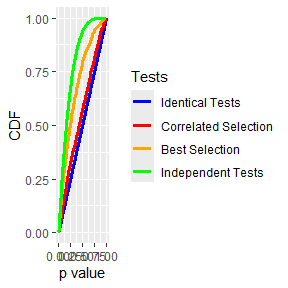

```r
tmp=Rgof::pvaluecdf
Tests=factor(c(rep("Identical Tests", nrow(tmp)),
        rep("Correlated Selection", nrow(tmp)),
        rep("Best Selection", nrow(tmp)),
        rep("Independent Tests", nrow(tmp))),
        levels=c("Identical Tests",  "Correlated Selection",
                 "Best Selection", "Independent Tests"),
        ordered = TRUE)
dta=data.frame(x=c(tmp[,1],tmp[,1],tmp[,1],tmp[,1]),
          y=c(tmp[,1],tmp[,3],tmp[,2],1-(1-tmp[,1])^4),
          Tests=Tests)
ggplot2::ggplot(data=dta, ggplot2::aes(x=x,y=y,col=Tests))+
  ggplot2::geom_line(linewidth=1.2)+
  ggplot2::labs(x="p value", y="CDF")+
  ggplot2::scale_color_manual(values=c("blue","red", "Orange", "green"))
```

Here is how to find these adjusted p values with *Rgof*:

```r
x=rnull()
```

[output not shown]

```r
Rgof::gof_test_adjusted_pvalue(x, NA, pnull, rnull,
              B=c(100, 100), maxProcessor = 1)
```

[output not shown]

[output cut: 153 more lines]

[output not shown]

### Weighted Data

Sometimes the data/model uses importance sampling weights. This can be done as follows. Say we want to test whether the data comes from a standard normal distribution, truncated to [-3,3] and with weights from a t distribution with 3 degrees of freedom:

$H_0: F=N(0,1)$, $X\sim t(3)$

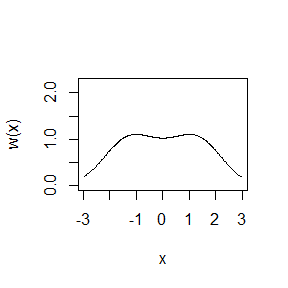

```r
df=3
pnull=function(x) pnorm(x)/(2*pnorm(3)-1)
rnull=function() {x=rt(2000, df);x=x[abs(x)<3];sort(x[1:1000])}
w=function(x) (dnorm(x)/(2*pnorm(3)-1))/(dt(x,df)/(2*pt(3,df)-1))
x=sort(rnull())
plot(x, w(x), type="l", ylim=c(0, 2*max(w(x))))
```

```r
ralt=function(m=0) {x=rt(2000,df)+m;x=x[abs(x)<3];sort(x[1:1000])}
set.seed(111)
Rgof::gof_power(pnull, NA, rnull, ralt, w=w, param_alt = c(0,0.2), Range=c(-3,3),B=Bsim)
```

```
#> maxProcessor set to 1 for faster computation
#>        KS     K   CvM   AD
#> 0   0.064 0.064 0.052 0.05
#> 0.2 1.000 1.000 1.000 1.00
```

It should be noted that these tests are quite sensitive to the size of the weights and to the sample size, so one should always do a simulation study to verify that they work in the case under consideration.

### Case Studies

The package includes the routine *run.studies*, which provides 20 case studies each for the continuous and the discrete case. This allows the user to easily compare the power of the methods included in the package to a different one of their choice.

If the user supplied method only yields the test statistic, simulation is used to find the p value. If the new test can find p values, these are used and then the routine will of course run much faster.

Say a user wishes to study the performance of the chi square test for the case where the null hypothesis specifies a uniform distribution but the data actually comes from a linear distribution with slope s. (This test is of course already included in the package, so this is for illustration purposes only). So

```r
chitest=function(x, pnull, param, TSextra) {
    nbins=TSextra$nbins #number of bins
    bins=seq(min(x)-1e-10, max(x)+1e-10, length=nbins+1)
    O=hist(x, bins, plot=FALSE)$counts #bin counts
    if(param[1]!=-99) { #with parameter estimation
        E=length(x)*diff(pnull(bins, param)) #expected counts
        chi=sum((O-E)^2/E) #Pearson's chi square
        pval=1-pchisq(chi, nbins-1-length(param)) #p value
    }
    else {
      E=length(x)*diff(pnull(bins))
      chi=sum((O-E)^2/E)
      pval=1-pchisq(chi,nbins-1)
    }
    out=ifelse(TSextra$statistic, chi, pval)
    names(out)="ChiSquare"
    out
}
```

In this example we find the power of *chitest* when the null hypothesis specifies a uniform distribution but the true distribution is a linear with slope s:

```r
TSextra=list(nbins=5, statistic=FALSE)
pwr=Rgof::run.studies(chitest, "uniform.linear", TSextra=TSextra, With.p.value=TRUE)
```

```
#> Running case uniform.linear.cont ...
```

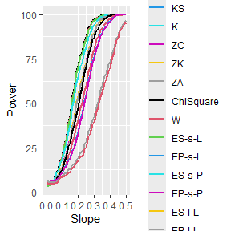

```r
Rgof::plot_power(pwr, "Slope")
```

Arguments of *run.studies*:

- study: either the name(s) or position(s) of the desired sudies in the list of all studies
- TS: new test statistic
- study: the name of the case study. If missing all 20 are run
- TSextra: a list passed to TS
- With.p.value =FALSE set to TRUE if the user supplied method calculates p values
- BasicComparison = TRUE: if TRUE one value of the parameters under the alternative is chosen for each case study and all 20 studies are run
- nsample =500: desired sample size.
- alpha = 0.05: desired true type I error probability
- param_alt: a vector of values of the parameter of the alternative distribution. If missing the ones included in Rgof are used. If more than one study is run this needs to be a list of vectors
- B=c(1000, 1000) number of simulation runs

The arguments of the user supplied test routine have to be

**Continuous Data:**

- x: the data set
- pnull: a routine to calculate the distribution function
- param: if parameters of pnull are estimated, this is vector of parameter estimates. If no parameters are estimated, this is ignored but has to be present.
- TSextra: a list with any object needed to calculate the test statistic / p value.

**Discrete Data**

- x: the data set (the counts)
- pnull: a routine to calculate the distribution function
- param: if parameters of pnull are estimated, this is vector of parameter estimates. If no parameters are estimated, this is ignored but has to be present.
- vals: the possible values of the discrete random variable.
- TSextra: a list with any object needed to calculate the test statistic / p value.

In either case the output of the routine has to be a named vector with either the test statistic(s) or the p values(s).

The case studies are as follows. In each the first term specifies the model under the null hypothesis and the second the model under the alternative hypothesis. The cases studies with names ending in .est include parameter estimation.

**Without parameter estimation**

1. uniform.linear$\hspace{3cm}$ U[0,1] vs a linear model on [0,1] with slope s.
2. uniform.quadratic$\hspace{2.5cm}$ U[0,1] vs a quadratic model with vertex at 0.5 and some curvature a.
3. uniform.bump$\hspace{3.1cm}$ U[0,1] vs U[0,1]+N(0.5,0.05).
4. uniform.sine$\hspace{3.3cm}$ U[0,1] vs U[0,1]+Sine wave
5. beta22.betaaa$\hspace{3cm}$ Beta(2,2) vs Beta(a,a)
6. beta22.beta2a$\hspace{3cm}$ Beta(2,2) vs Beta(2,a)
7. normal.shift$\hspace{3.5cm}$ N(0,1) vs N($\mu$,1)
8. normal.stretch$\hspace{3.1cm}$ N(0,1) vs N(0, $\sigma$)
9. normal.t$\hspace{4.2cm}$ N(0,1) vs t(df)
10. normal.outlier1$\hspace{3.1cm}$ N(0,1) vs N(0,1)+U[2,3]
11. normal.outlier2$\hspace{3.1cm}$ N(0,1) vs N(0,1)+U[-3,-2]+U[2,3]
12. exponential.gamma$\hspace{2.3cm}$ Exp(1) vs Gamma(1,b)
13. exponential.weibull$\hspace{2.5cm}$ Exp(1) vs Weibull(1,b)
14. exponential.bump$\hspace{2.7cm}$ Exp(1) vs Exp(1)+N(0.5,0.05)
15. trunc.exponential.linear$\hspace{1.7cm}$ Exp(1) vs Linear, on [0,1]

**With parameter estimation**

16. normal.t.est$\hspace{3.7cm}$ N($\mu$,$\sigma$) vs t(df)
17. exponential.weibull.est$\hspace{1.9cm}$ Exp($\lambda$) vs Weibull(1,b)
18. trunc.exponential.linear.est$\hspace{1.2cm}$ Exp($\lambda$) vs Linear, on [0,1]
19. exponential.gamma.est$\hspace{1.8cm}$ Exp($\lambda$) vs Gamma(1,b)
20. normal.cauchy.est$\hspace{2.7cm}$ N($\mu$,$\sigma$) vs Cauchy (Breit-Wigner)

Generally a user will likely wish to run all the included case studies. This is very easily done with

```r
Rgof::run.studies(chitest, TSextra=TSextra, With.p.value=TRUE)
```

If only the test statistic is supplied by the new test and therefore simulation has to be used to find p values, this will take several hours to run. *run.studies* can also be used to run the studies for the included methods but for different values of param_alt, nsample and/or alpha. For example, say we wish to find the powers of the included continuous methods for the case uniform.linear and samples of size 2000, slopes of 0.1 and 0.2, and a true type I error of 0.01:

```r
Rgof::run.studies(TRUE, # continuous data/model
                  study="uniform.linear",
                  param_alt=c(0.1, 0.2),
                  nsample=2000,
                  alpha=0.01)
```

# References

Anderson, T W. 1962. “On the Distribution of the Two-Sample Cramer-von Mises Criterion.” *Annals of Mathematical Statistics* 33 (3): 1148–59.

Anderson, T W, and D A Darling. 1952. “Asymptotic Theory of Certain Goodness-of-Fit Criteria Based on Stochastic Processes.” *Annals of Mathematical Statistics* 23: 193–212.

———. 1954. “A Test of Goodness-of-Fit.” *JASA* 49: 765–69.

Berkson, J. 1980. “Minimum Chi-Square, Not Maximum Likelihood.” *Ann. Math. Stat* 8 (3): 457–87.

E del Barrio, C Matran, J A Cuesta-Albertos. 1999. “Tests of Goodness of Fit Based on the L2-Wasserstein Distance.” *Annals of Statistics* 1230-1239: 27.

Kolmogorov, A. 1933. “Sulla Determinazione Empirica Di Una Legge Di Distribuzione.” *G. Ist. Ital. Attuari.* 4: 83–91.

Kuiper, N H. 1960. “Tests Concerning Random Points on a Circle.” *Proceedings of the Koninklijke Nederlandse Akademie van Wetenschappen* 63: 38–47.

Massey, F J. 1951. “The Kolmogorov-Smirnov Test for Goodness-of-Fit.” *JASA* 46: 68–78.

Rolke, Wolfgang, and Cristian Gutierrez-Gongora. 2020. “A Chi-Square Goodness-of-Fit Test for Continuous Distributions Against a Known Alternative.” *Computational Statistics*. https://doi.org/10.1007/s00180-020-00997-x.

Smirnov, N. 1948. “Table for Estimating the Goodness of Fit of Empirical Distributions.” *Annals of Mathematical Statistics* 19: 279–81.

Zhang, J. 2002. “Powerful Goodness-of-Fit Tests Based on Likelihood Ratio.” *Journal of the RSS (Series B)* 64: 281–94.